# 04_C_TSGraphs_Lagplots_Autocorrelation

```r
library(fpp3)
```

# References

This is not original material but a compilation of the following sources with some additional examples and clarifications introduced by the professor:

1. Hyndman, R.J., & Athanasopoulos, G., 2021. *Forecasting: principles and practice*, 3rd edition — [sections 2.7 to 2.9](https://otexts.com/fpp3/graphics.html), covered here in the same order.
2. Additional material provided by the book authors

# Lagged variables and time-plots

Given a time series, we can compute its lags by shifting it in time a given number of steps. A lagged variable holds the same information as the original, shifted by the number of steps indicated by the lag.

In more technical terms: given a variable $x_t$, its lags are **delayed versions of the variable**, with the lag number indicating the time delay:

- The first lag of $x_t$ is written $x_{t-1}$. At any point in time $t$, the value of $x_{t-1}$ is the value of $x_t$ one time step ago.
- The second lag of $x_t$ is written $x_{t-2}$. At any point in time $t$, the value of $x_{t-2}$ is the value of $x_t$ two time steps ago.
- …
- The n-th lag of $x_t$ is written $x_{t-n}$. At any point in time $t$, the value of $x_{t-n}$ is the value of $x_t$ $n$ time steps ago.

Lagged variables matter in time series analysis for two main reasons:

1. Studying the relationship between the lags {$x_{t-1}$, $x_{t-2}$, $\cdots$, $x_{t-n}$} and $x_t$ tells us **whether the variable** $x_t$ is related to its own past values.
2. Studying the relationship between the lags {$x_{t-1}$, $x_{t-2}$, $\cdots$, $x_{t-n}$} and a second variable $y_t$ tells us **whether** $y_t$ is related to the past behavior of $x$.
   - **A typical business case:** current sales might be related to marketing investment made some time steps ago.

An example makes this concrete:

```r
recent_beer <- aus_production |>
  filter(year(Quarter) >= 2000) |>
  select(Quarter, Beer)

recent_beer
```

```
# A tsibble: 42 x 2 [1Q]
   Quarter  Beer
     <qtr> <dbl>
 1 2000 Q1   421
 2 2000 Q2   402
 3 2000 Q3   414
 4 2000 Q4   500
 5 2001 Q1   451
 6 2001 Q2   380
 7 2001 Q3   416
 8 2001 Q4   492
 9 2002 Q1   428
10 2002 Q2   408
# ℹ 32 more rows
```

This code generates the lagged values of the variable *Beer*:

```r
for (i in seq(1, 4)) {
  lag_name = paste0("Beer_lag", as.character(i))
  recent_beer[[lag_name]] = lag(recent_beer[["Beer"]], i)
}

recent_beer
```

```
# A tsibble: 42 x 6 [1Q]
   Quarter  Beer Beer_lag1 Beer_lag2 Beer_lag3 Beer_lag4
     <qtr> <dbl>     <dbl>     <dbl>     <dbl>     <dbl>
 1 2000 Q1   421        NA        NA        NA        NA
 2 2000 Q2   402       421        NA        NA        NA
 3 2000 Q3   414       402       421        NA        NA
 4 2000 Q4   500       414       402       421        NA
 5 2001 Q1   451       500       414       402       421
 6 2001 Q2   380       451       500       414       402
 7 2001 Q3   416       380       451       500       414
 8 2001 Q4   492       416       380       451       500
 9 2002 Q1   428       492       416       380       451
10 2002 Q2   408       428       492       416       380
# ℹ 32 more rows
```

If we call beer $y_t$ (the time series we are studying), the formal notation for the variables above is:

- $y_t \rightarrow$ `Beer` production, the variable we are studying
- $y_{t-1} \rightarrow$ `Beer_lag1` - first lag of the variable beer
- $y_{t-2} \rightarrow$ `Beer_lag2` - second lag of the variable beer
- $y_{t-3} \rightarrow$ `Beer_lag3` - third lag of the variable beer
- $y_{t-4} \rightarrow$ `Beer_lag4` - fourth lag of the variable beer

Note that:

- Shifting the variable leaves a gap at the start: there is no earlier data to fill those rows, so R fills them with *NA*.
  - **The lagged variables are time series too, but shorter than the original variable because of these NAs.**
- The rest of the values in the time series stay the same.

This results in the following structure of NAs as the lag number increases:

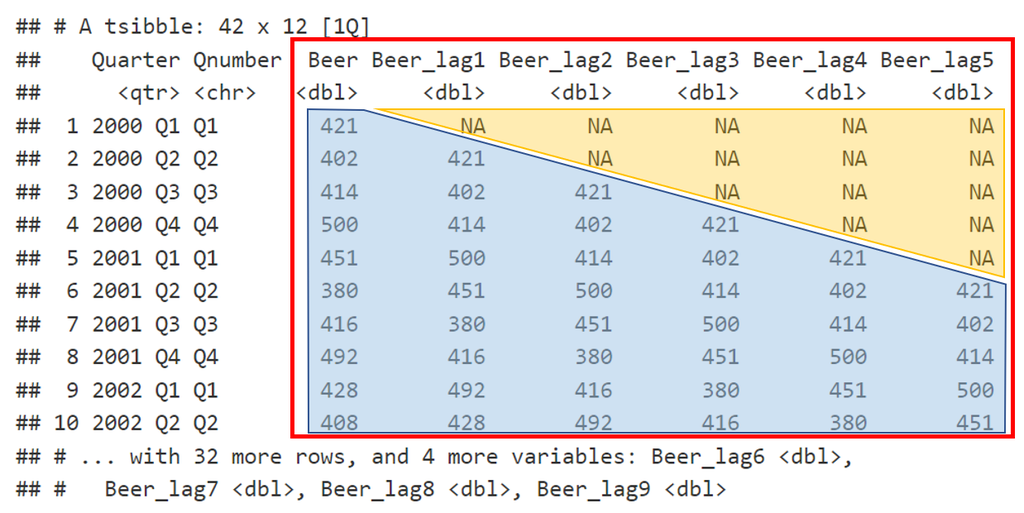

Let us now create a timeplot of these lags. If we focus on `Beer` ($y_t$) and `Beer_lag4` ($y_{t-4}$), we can see that **each value of `Beer` is drawn alongside its value 4 time steps earlier**. For example, at `2001 Q1` the plot shows beer production that quarter next to production at `2000 Q1`, exactly four time steps earlier.

```r
recent_beer |> select(Beer, Beer_lag4)
```

```
# A tsibble: 42 x 3 [1Q]
    Beer Beer_lag4 Quarter
   <dbl>     <dbl>   <qtr>
 1   421        NA 2000 Q1
 2   402        NA 2000 Q2
 3   414        NA 2000 Q3
 4   500        NA 2000 Q4
 5   451       421 2001 Q1
 6   380       402 2001 Q2
 7   416       414 2001 Q3
 8   492       500 2001 Q4
 9   428       451 2002 Q1
10   408       380 2002 Q2
# ℹ 32 more rows
```

The code below creates a time-plot of both variables. Change `n_lag` to plot another lag: try 1 and 3 (the lines drift apart) and 2 (peaks land on troughs).

```
Plot variable not specified, automatically selected `.vars = Beer`
```

```
Warning: `aes_string()` was deprecated in ggplot2 3.0.0.
ℹ Please use tidy evaluation idioms with `aes()`.
ℹ See also `vignette("ggplot2-in-packages")` for more information.
```

```
Warning: Removed 4 rows containing missing values or values outside the scale range
(`geom_line()`).
```

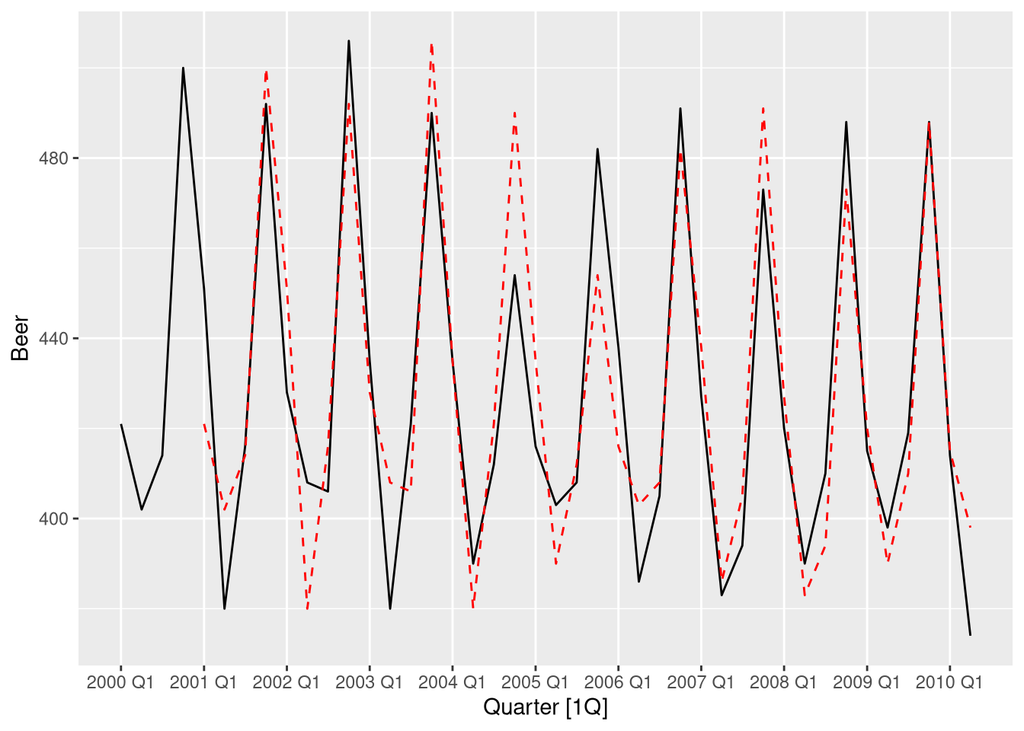

```r
n_lag = 4
lag_name = paste0("Beer_lag", n_lag)

recent_beer |>
  autoplot() +
  scale_x_yearquarter(breaks = "1 years",
                      minor_breaks = "1 year") +
  # aes_string() lets us pass the column name held in a variable. It was
  # deprecated in ggplot2 3.0.0 and still works; the modern idiom for the
  # same job is aes(x = Quarter, y = .data[[lag_name]]).
  geom_line(aes_string(x = "Quarter", y = lag_name),
            color = "red",
            linetype = "dashed")
```

Two warnings are expected here, and neither is a bug: the `aes_string()` deprecation above, and `Removed 4 rows containing missing values`, which are the four NAs at the top of `Beer_lag4`.

For the 4th lag, the lagged variable and the original variable are perfectly *in phase*. This happens because the series has a seasonal period of 1 year (4 quarters) and simple seasonality, meaning only this yearly pattern is present.

Shifting by half a period (here, 2 quarters) puts the peaks on top of the troughs. That is *anti-phase*: a strong relationship, but an inverted one, not the absence of a relationship.

# Lagged-variables and scatterplots. Autocorrelation.

Lagged variables let us study how much the value of the series at time $t$ depends on its values at past time steps.

Let us build a scatterplot showing the relationship between the fourth lag of `Beer` and the original variable. Here we set time aside and plot the values of `Beer` against its fourth lag, `Beer_lag4`. These are the values highlighted in yellow in the tsibble below (NAs are excluded):

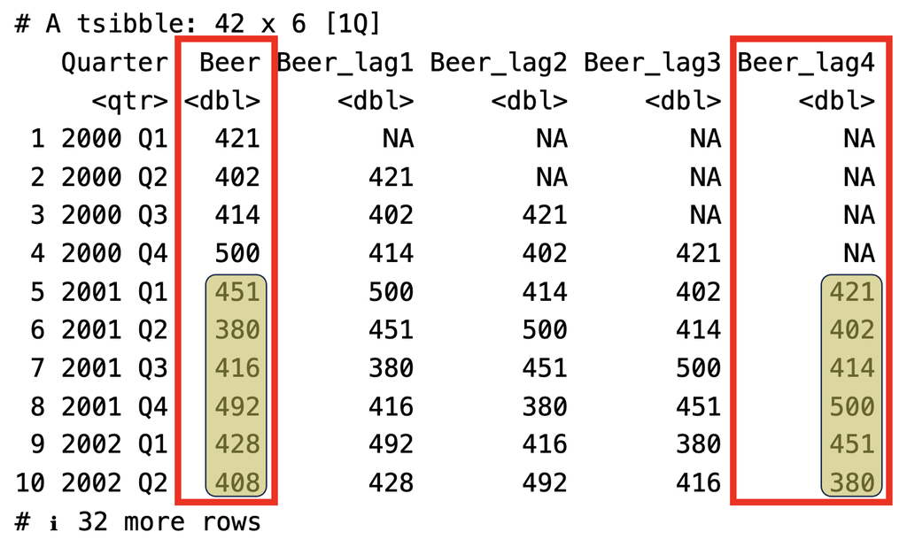

The code that produces it is:

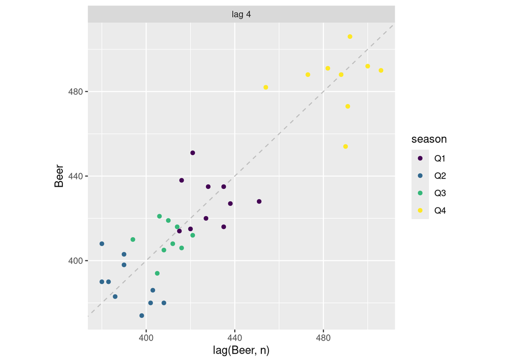

```r
recent_beer |>
  gg_lag(y = Beer, geom = "point", lags = 4)
```

Each point is one quarter: its y-coordinate is production that quarter, its x-coordinate is production four quarters earlier. The dashed diagonal is the line $y = x$, drawn for reference, not a fitted line.

We could summarize the **degree of linear relationship between these two variables** using, for example, **Pearson’s correlation coefficient**. As we will see, time series analysis has a better-suited metric for this purpose.

Let us compute these scatterplots for a range of lags. Together, they form what we call **a lagplot** of the time series:

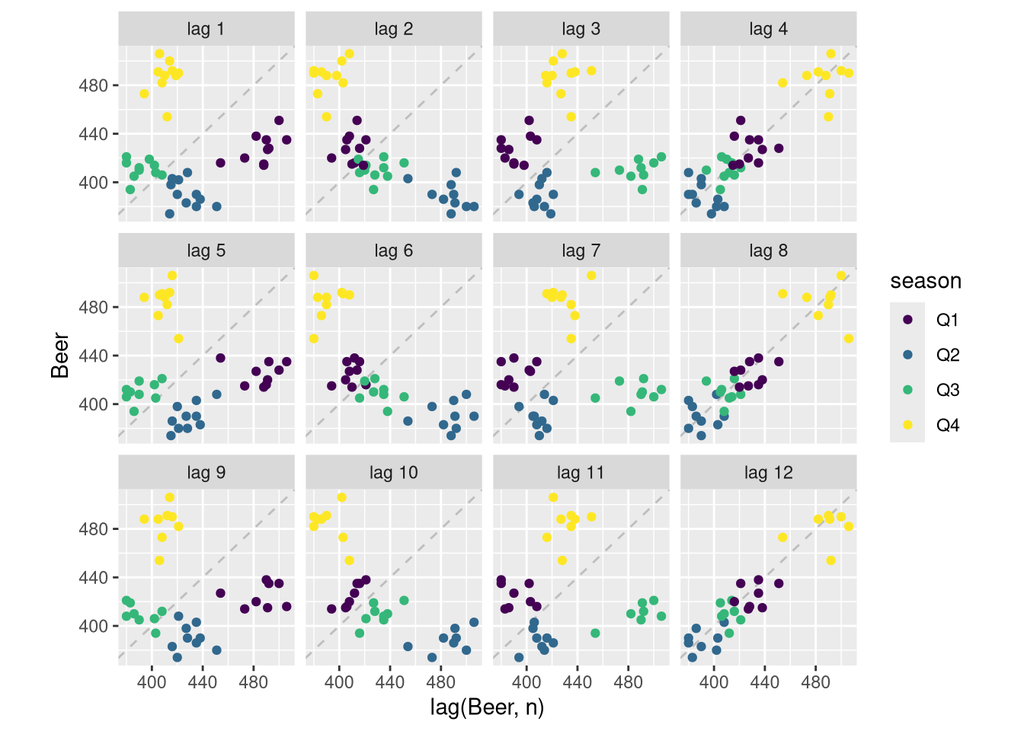

```r
recent_beer |>
  gg_lag(y = Beer, geom = "point", lags = 1:12)
```

In the figure above, notice that **the relationship between the variable and its lags is much stronger at the multiples of the seasonal period (lags 4, 8 and 12, with** $m = 4$).

Read the panels for *tightness*, not for direction:

- **Lags 4, 8, 12** — tight upward diagonals. The series is in phase with itself.
- **Lags 2, 6, 10** — tight *downward* diagonals. Half a period back, peaks sit on troughs. This is anti-phase, and it is just as much memory as an upward cloud.
- **Odd lags** — blobs. A quarter of the way round the cycle, highs and lows are mixed and nothing systematic survives.

## Autocorrelation vs. Pearson’s correlation coefficient

Let us recall the formula for Pearson’s correlation coefficient between two variables `x` and `y`

$$\begin{align*}
r = \frac{\sum(x_{i}-\bar{x})(y_{i}-\bar{y})}
{\sqrt{\sum(x_{i}-\bar{x})^2\sum(y_{i}-\bar{y})^2}}
\end{align*}$$

The lagplot above stops at twelve panels, but `ACF()` will compute sixteen coefficients for this series by default, so think of the formula being applied at each of those sixteen lags. We would get sixteen coefficients computed on sixteen different sets of pairs, because **the lagged time series has fewer points than the original series**: 41 pairs at lag 1, 26 pairs at lag 16. Pearson’s formula normalizes by the spread of *the pairs it used*, so both its numerator and its denominator would shrink with the lag. The yardstick would change underneath us at every lag.

We want one yardstick for all sixteen. So we build a **new correlation coefficient**: we keep the same numerator, and **fix the denominator to the spread of the whole series**, so that only the part being measured shrinks. The consequence is deliberate — **a lag further in the past carries less influence over the original time series**. This is what we call the **autocorrelation coefficient between the time series** $y_t$ and its k-th lag $y_{t-k}$:

$$\begin{align*}
r_{k} = \frac{\sum\limits_{t=k+1}^T (y_{t}-\bar{y})(y_{t-k}-\bar{y})}
{\sum\limits_{t=1}^T (y_{t}-\bar{y})^2}
\end{align*}$$

In the above formula:

- $t = 1$ is the first point in the time series.
- $t = T$ is the last point for which we have recorded data.
- **The denominator stays the same for the correlation coefficient of every lag.** Its sum extends over the entire original time series (from $t=1$ to $t=T$).
- **The numerator has fewer terms as** $k$ (the lag number) increases. Its sum extends from $k+1$ to $T$.
- **Example:** if $k = 1$ (first lag), the first value of the lagged series ($t=1$) is an `NA`. The sum therefore starts at $t=k+1=2$ and runs to the end.
- $\bar{y}$ is the mean of the **whole** series in both sums, including in the $y_{t-k}$ factor. It is not the mean of the lagged column.

Because the denominator stays constant while the numerator shrinks as $k$ increases, **the autocorrelation coefficient is inherently pulled down for lags further in the past**.

This does not mean autocorrelation coefficients for older lags cannot be high. It means the coefficient has a built-in scaling that depends on how far back the lag reaches. Think of a photograph rather than a jury: everything stays in frame, and things further away are drawn smaller. Nothing is excluded, and you can still tell a mountain from a pebble.

The penalty is gentle for a long series, since the numerator loses only $k$ terms out of $T$, and sharper for a short one. That is one more reason not to read the far right-hand end of a short correlogram too confidently.

## Computing the autocorrelation coefficients in R

The `ACF()` function computes the autocorrelation coefficients:

```r
recent_beer |>
  ACF()
```

```
Response variable not specified, automatically selected `var = Beer`
```

```
# A tsibble: 16 x 2 [1Q]
        lag      acf
   <cf_lag>    <dbl>
 1       1Q -0.0530
 2       2Q -0.758
 3       3Q -0.0262
 4       4Q  0.802
 5       5Q -0.0775
 6       6Q -0.657
 7       7Q  0.00119
 8       8Q  0.707
 9       9Q -0.0888
10      10Q -0.588
11      11Q  0.0241
12      12Q  0.632
13      13Q -0.0660
14      14Q -0.505
15      15Q -0.00891
16      16Q  0.498
```

The output is a tsibble with one column of lags and one of coefficients, so you can `filter()` and `arrange()` it like any other — useful when you want the largest coefficient rather than a picture. Note that the lag column prints as `4Q` rather than `4`: it carries the interval of the original series, which is what stops you from silently comparing a correlogram of quarterly data with one of monthly data.

## ACF Plot (a.k.a *Correlogram*)

If we compute the autocorrelation coefficient for each lag, we can plot them on a graph:

- **x-axis**: the lag number.
- **y-axis**: the value of the corresponding autocorrelation coefficient.

This graph is the correlogram. `autoplot()` builds it directly from the ACF output:

```
Response variable not specified, automatically selected `var = Beer`
```

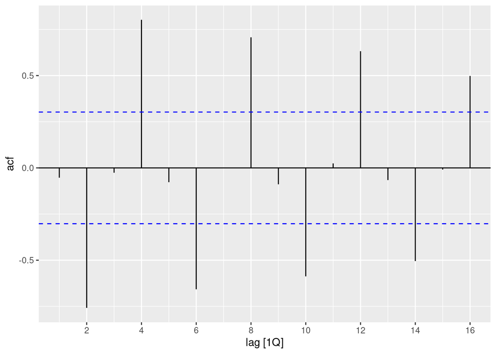

```r
recent_beer |>
  ACF() |>
  autoplot()
```

### How many lags to show

The `lag_max` argument sets the number of lags computed and shown in the correlogram. **This matters because seasonality only appears in the correlogram once enough lags have been computed** — you need at least one full seasonal cycle, and ideally two or more.

`lag_max` counts in the units of the index. The 24 below means 24 *quarters*, that is six years. The same number would mean two years of monthly data, or under half a year of weekly data. Exercise 4 is where this bites.

```
Response variable not specified, automatically selected `var = Beer`
```

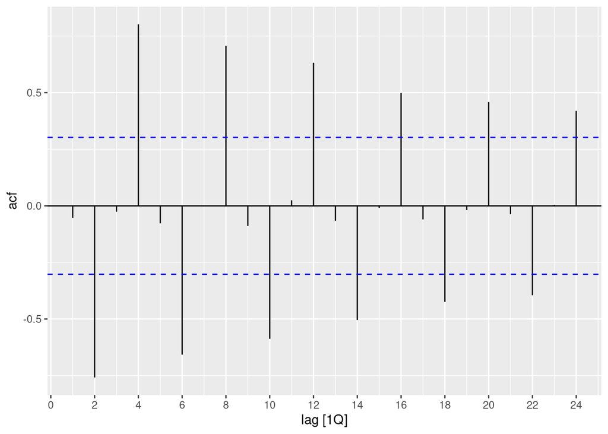

```r
recent_beer |>
  ACF(lag_max = 24) |>
  autoplot()
```

## Trend and seasonality in ACF plots

Study this section carefully: assignments and exams will ask you to recognize these patterns and their subtleties.

When data have a **trend:**

- The **autocorrelation coefficients for small lags** tend to be **large and positive**, because **observations nearby in time are also nearby in value**. As a result, the ACF of a trended time series tends to show **positive values that slowly decrease as the lags increase**.
- In the figure below, **focus only on the region circled in red, not on the region where the ACF turns negative.** The pattern that signals a trend is this slow, positive decay at the start of the correlogram; where the ACF drifts below zero is the same decay continuing, and it tells you nothing extra.

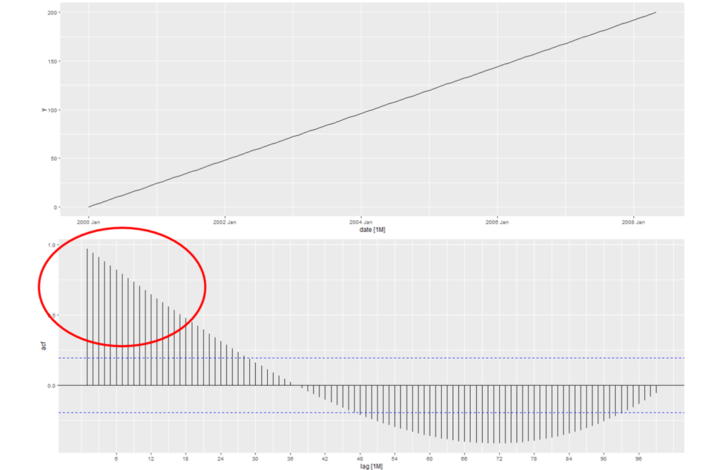

- The same pattern holds for a negative trend:

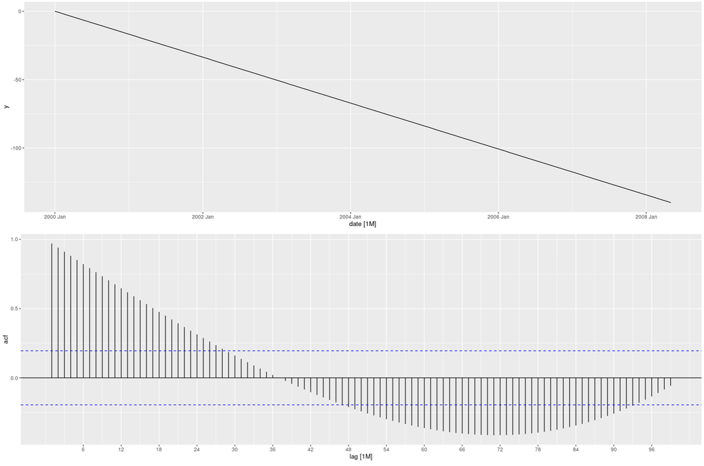

When data are **seasonal:**

- The autocorrelation **is larger at the seasonal lags (multiples of the seasonal period) than at other lags.**
  - The autocorrelation at higher multiples of the seasonal period is smaller than at lower multiples, because the higher multiples reach further into the past and, as explained above, the autocorrelation formula accounts for this. The seasonality itself is not weakening.
  - **The half-period lags go deeply negative**, because a shift of $m/2$ puts peaks on troughs. For `recent_beer` ($m = 4$) that is lags 2, 6 and 10; for monthly data ($m = 12$) it is lags near 6, 18 and 30. If those negative dips are missing and every bar sits above zero, a trend is holding the whole correlogram up.

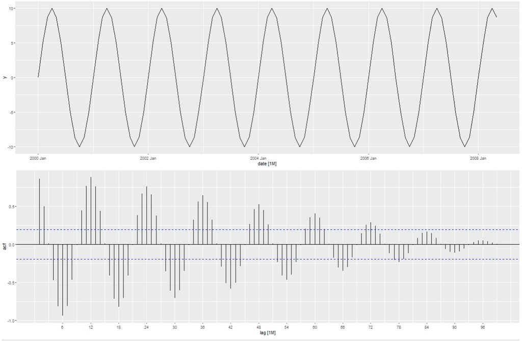

When data are **both trended and seasonal:**

- The correlogram shows a combination of both effects. The exact pattern depends on the **relative strength of the trend and the seasonality**. Below are some of the most common cases, generated using this Shiny app:

[Web-app - Time Series autocorrelation - basic patterns](https://tel5cn-juan-garbayo.shinyapps.io/shiny_tseriesacf/)

- **Seasonal and trend data are of the same order** (one does not dominate over the other):

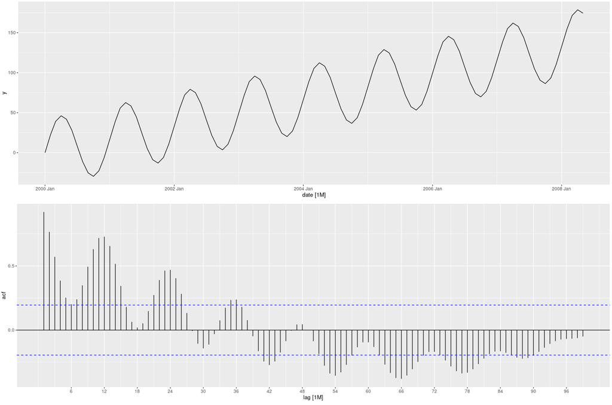

Let us look at the example of the sales of Australian antidiabetic drugs:

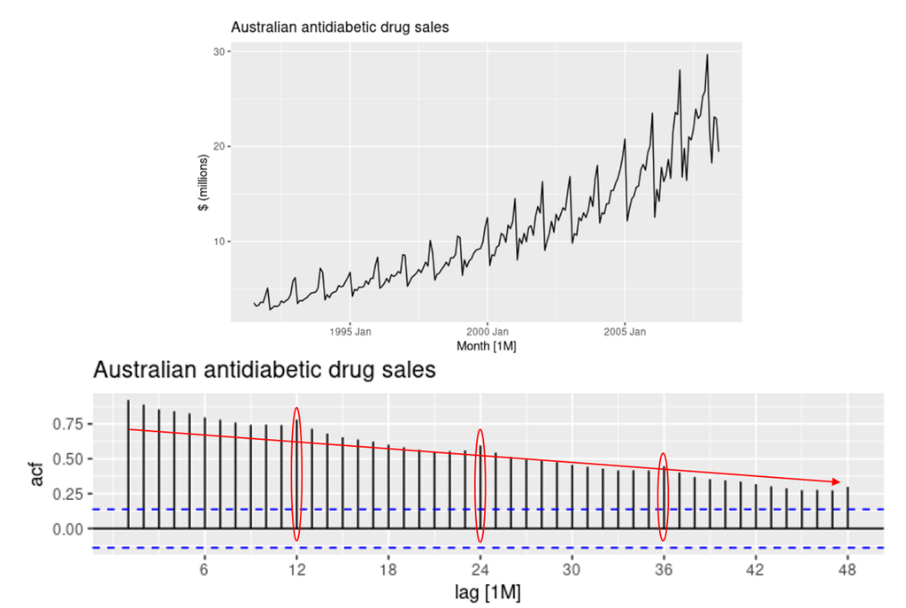

- **Seasonal component weaker than trend component**: waves from the seasonal component are visible on the ACF, but the ACF alone does not reveal the actual seasonal period (lag 12 is not clearly higher than its neighbors). **What is lost here is the period, not the existence of a pattern.** Time series decomposition (next session) will let us extract the seasonal component.

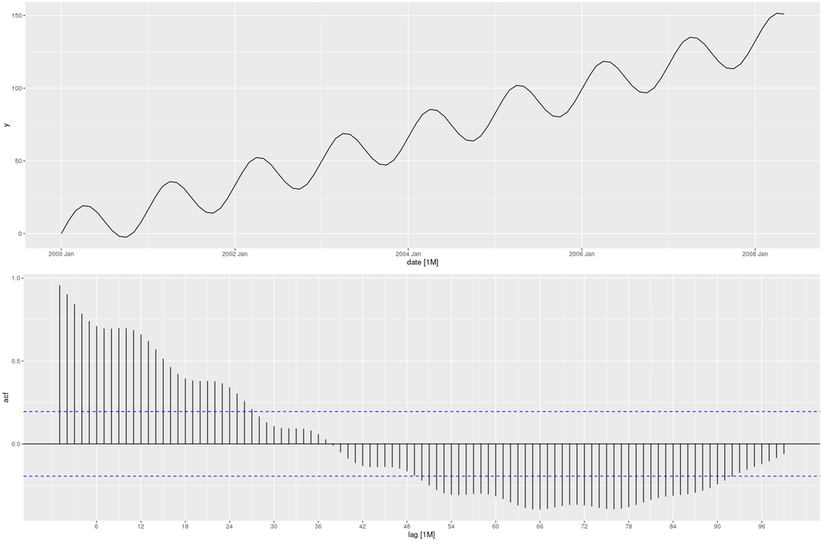

- **Seasonal component much weaker than trend component**: the ACF looks like that of a pure trend. **This does not mean there is no seasonality, only that the ACF does not reflect it.** Time series decomposition (next session) will let us extract the seasonal component.

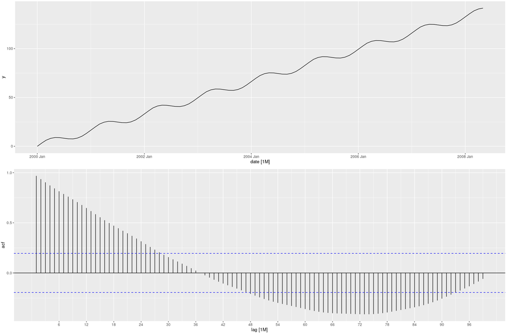

Another case worth considering: **when the trend component is much weaker than the seasonal component**, the trend is barely noticeable on the correlogram. Again, this does not mean there is no trend, only that the seasonal component masks it. This failure mode gets less attention than it deserves: people report “seasonal, no trend” from a series that is clearly drifting on its time plot.

The rule that covers all of these cases: **when the correlogram disagrees with the time plot, the time plot wins.** A summary can hide a component; a picture of the data cannot.

# White noise

Time series that show no autocorrelation are called white noise. That is the definition: knowing $y_{t-k}$ tells us nothing about $y_t$, for every $k$. It is not the same as “looks messy”.

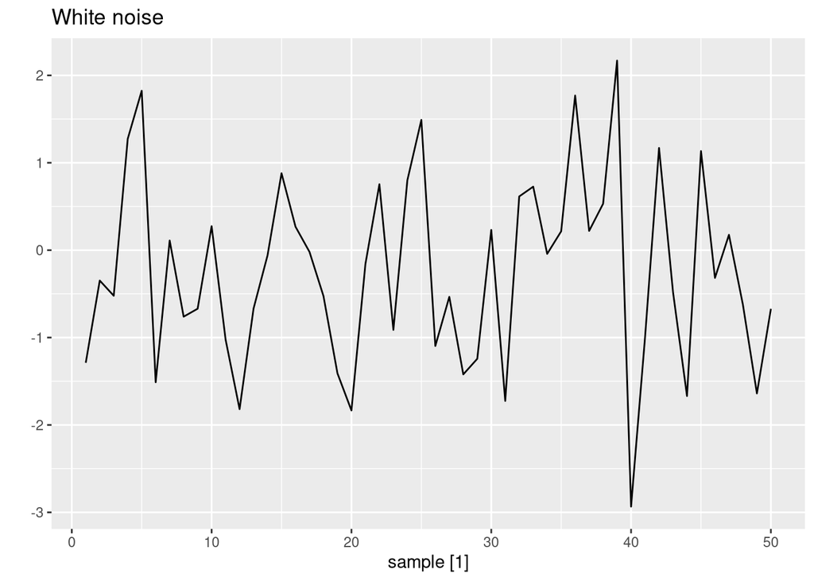

```r
# Fixes the starting state of R's random number generator, so rnorm(50)
# returns the same fifty numbers on every machine.
set.seed(30)

y <- tsibble(sample = 1:50, wn = rnorm(50), index = sample)

y |> autoplot(wn) + labs(title = "White noise", y = "")
```

The series above draws from a normal distribution, so we call it **Gaussian white noise**:

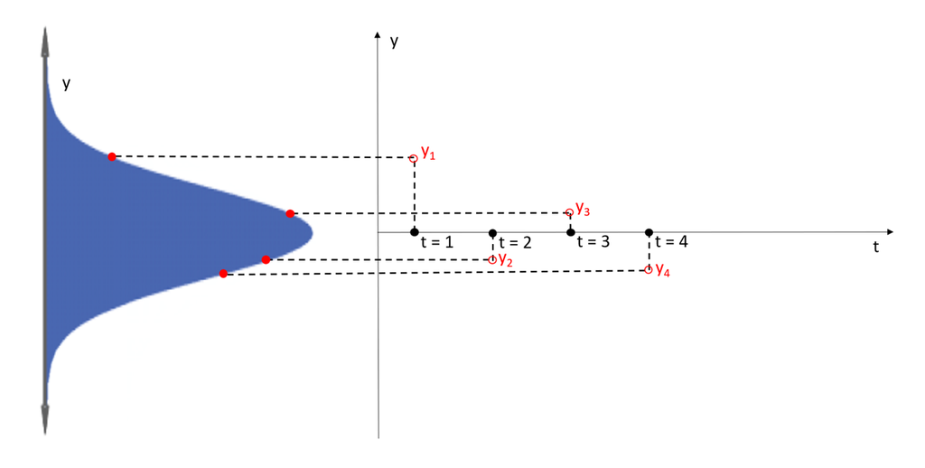

Note that white noise does not have to be Gaussian. The definition requires zero autocorrelation with a constant mean and variance; normality is an extra assumption, convenient and often reasonable, and it is what `rnorm()` supplies here.

Let’s look at the correlogram:

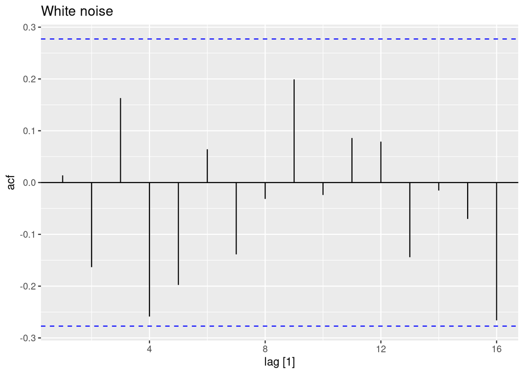

```r
y |>
  ACF(wn) |>
  autoplot() + labs(title = "White noise")
```

For a white noise series, autocorrelation is expected to be close to zero, but random variation will keep it from landing exactly there.

- We expect 95% of the spikes in the ACF to lie within $\pm 2/\sqrt{T}$, where $T$ is the length of the time series. Here $T = 50$, so the bounds sit at $\pm 2/\sqrt{50} = \pm 0.283$. `autoplot()` draws them as dashed blue lines.
- Checking this is similar to running a separate statistical test on each autocorrelation coefficient.
  - This means we may see false positives. Across 20 lags, roughly one spike outside the bounds is the expected result, not a surprise.
- The bounds narrow as the series gets longer: $\pm 0.28$ at $T = 50$, $\pm 0.06$ at $T = 1000$. A long series lets us detect a much weaker memory.

The time series is probably not white noise if:

- one or more **large spikes** fall outside these bounds — clearly outside, not grazing the line — or
- substantially more than 5% of the spikes fall outside these bounds.

Note the asymmetry: crossing the bounds is evidence *against* white noise, but staying inside them is not proof *of* white noise. It is a failure to find evidence, on a test that is weak for short series.

Later in the course, we will see a statistical test that checks multiple autocorrelation coefficients at once. For now, the two criteria above are enough.

# Exercise 1 - ACF Plot patterns

With the concepts we have seen in this class, you should be able to tell which time series corresponds to each correlogram.

Classify each correlogram on its own before attempting any pairing — envelope, rhythm, sign, scale — then do the same for the time plots and match on the strongest discriminating feature. When you finish, check that every correlogram is claimed exactly once.

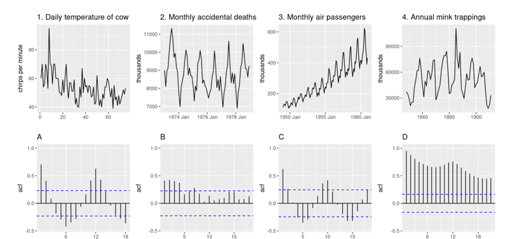

# Exercise 2 - time series graphs

Use the following graph functions: `autoplot()`, `ACF()` and explore features of the time series `Total Private` from the dataset `us_employment` (loaded with `fpp3`):

```r
us_employment
```

```
# A tsibble: 143,412 x 4 [1M]
# Key:       Series_ID [148]
      Month Series_ID     Title         Employed
      <mth> <chr>         <chr>            <dbl>
 1 1939 Jan CEU0500000001 Total Private    25338
 2 1939 Feb CEU0500000001 Total Private    25447
 3 1939 Mar CEU0500000001 Total Private    25833
 4 1939 Apr CEU0500000001 Total Private    25801
 5 1939 May CEU0500000001 Total Private    26113
 6 1939 Jun CEU0500000001 Total Private    26485
 7 1939 Jul CEU0500000001 Total Private    26481
 8 1939 Aug CEU0500000001 Total Private    26848
 9 1939 Sep CEU0500000001 Total Private    27468
10 1939 Oct CEU0500000001 Total Private    27830
# ℹ 143,402 more rows
```

```r
total_private <- us_employment |>
  filter(Title == "Total Private")

total_private
```

```
# A tsibble: 969 x 4 [1M]
# Key:       Series_ID [1]
      Month Series_ID     Title         Employed
      <mth> <chr>         <chr>            <dbl>
 1 1939 Jan CEU0500000001 Total Private    25338
 2 1939 Feb CEU0500000001 Total Private    25447
 3 1939 Mar CEU0500000001 Total Private    25833
 4 1939 Apr CEU0500000001 Total Private    25801
 5 1939 May CEU0500000001 Total Private    26113
 6 1939 Jun CEU0500000001 Total Private    26485
 7 1939 Jul CEU0500000001 Total Private    26481
 8 1939 Aug CEU0500000001 Total Private    26848
 9 1939 Sep CEU0500000001 Total Private    27468
10 1939 Oct CEU0500000001 Total Private    27830
# ℹ 959 more rows
```

# Exercise 3 - time series graphs

The PBS dataset included in fpp3 contains Monthly Medicare Australia prescription data. Run `?PBS` on the console for further info.

We would like to focus on the prescriptions with ATC (Anatomical Therapeutic Chemical Index level 2) equal to H02. This group corresponds to corticosteroids for systemic use.

```r
PBS |>
  filter(ATC2 == "H02") |>
  select(ATC2, Month, Cost, everything()) |>
  arrange(Month)
```

```
# A tsibble: 816 x 9 [1M]
# Key:       Concession, Type, ATC1, ATC2 [4]
   ATC2     Month   Cost Concession   Type     ATC1  ATC1_desc ATC2_desc Scripts
   <chr>    <mth>  <dbl> <chr>        <chr>    <chr> <chr>     <chr>       <dbl>
 1 H02   1991 Jul 317384 Concessional Co-paym… H     Systemic… CORTICOS…   63261
 2 H02   1991 Jul  82929 Concessional Safety … H     Systemic… CORTICOS…   12211
 3 H02   1991 Jul  20178 General      Co-paym… H     Systemic… CORTICOS…    4013
 4 H02   1991 Jul   9304 General      Safety … H     Systemic… CORTICOS…    2101
 5 H02   1991 Aug 269891 Concessional Co-paym… H     Systemic… CORTICOS…   53528
 6 H02   1991 Aug 100602 Concessional Safety … H     Systemic… CORTICOS…   14827
 7 H02   1991 Aug  16519 General      Co-paym… H     Systemic… CORTICOS…    3397
 8 H02   1991 Aug  13894 General      Safety … H     Systemic… CORTICOS…    2970
 9 H02   1991 Sep 269703 Concessional Co-paym… H     Systemic… CORTICOS…   52822
10 H02   1991 Sep 128900 Concessional Safety … H     Systemic… CORTICOS…   18896
# ℹ 806 more rows
```

1. As you can see, after filtering for `ATC2 == H02` there are 4 entries per month corresponding to different combinations of the columns `Concession` and `Type`. We would like to add the Cost associated to those 4 entries for every month, to obtain a time series of the total cost per month. Use `index_by()` and `summarise()` to get the total cost per month
2. Create and interpret the following graphs
- Time-plot with sufficient resolution to visually identify the seasonality
- ACF plots and lag plots to identify the seasonality

# Exercise 4 - time series graphs

The `us_gasoline` dataset, loaded with fpp3, contains weekly data on the **supply of US finished motor gasoline product**, from February 1991 to January 2017. Units are million barrels per day. This is the time series you need to analyze.

```r
head(us_gasoline)
```

```
# A tsibble: 6 x 2 [1W]
      Week Barrels
    <week>   <dbl>
1 1991 W06    6.62
2 1991 W07    6.43
3 1991 W08    6.58
4 1991 W09    7.22
5 1991 W10    6.88
6 1991 W11    6.95
```

Create and interpret the following graphs:

1. Timeplot with sufficient resolution to spot the beginning of each year.
2. Lagplots and correlogram to examine if there is any seasonality.